Home > Supervised Learning > Neural Networks

# 2.1.4.1 Neural Networks

The idea of neural networks is to generate nonlinearity through a so-called *activation function* $\sigma : \mathbb{R} \to \mathbb{R}$. Popular activation functions include $\text{ReLU} \sigma(t) = \max(t, 0), \text{Sigmoid } \sigma(t) = \frac{1}{1+e^{-t}}$ (squashes values to the range $[0, 1]$ which is useful for probabilities), the Heaviside function $\sigma(t) = 1_{t > 0}$, or the hyperbolic tangent $\sigma(t) = \text{tanh}(t)$ (squashes values to $[-1, 1]$, similar to sigmoid but centered at $0$). Now consider the basis function $x \mapsto \sigma (\langle w, x \rangle +b)$, which is also called a neuron. (takes an input $x$ applies a weight $w$, adds bias $b$ and passes the result through an activation function $\sigma$). This function is nonlinear but corresponds only to a shift and stretch of the activation function. (The dot product $\langle w, x \rangle + b$ shifts and stretches the input linearly). The activation function $\sigma$ then bends this linear combination into a **nonlinear** output. To obtain a better basis function, we form a linear combination of $n$ of these basis functions or neurons:

#### 2.1.21

$$\hat{f}(x) := \sum_{j=1}^n a_j \sigma
(\langle w_j, x \rangle + b_j)$$
Here:

- $n$: Number of neurons (the **width** of the network)
- $a_j$: Coefficient for the $j$-th neurons output
- $w_j, b_j$: Weight and bias for the $j$-th neuron

Key terminology

1. **Neuron**: The function $x \mapsto \sigma(\langle w_j, x \rangle + b_j)$
2. **Width** ($n$): The number of neurons in the hidden layer
3. **Weights** ($w_j$): Parameters controlling how inputs are combined
4. **Biases** ($b_j$): Parameters shifting the activation threshold
5. **Layers**:
   1. **Input layer**: Raw data $x$
   2. **Hidden layer**: Neurons ($j = 1,...,n$) processing inputs
   3. **Output layer**: The final prediction $\hat{f}(x)$ Each neuron contributes $d$ weights ($w_j \in \mathbb{R}^d$ for $d$-dimensional input), 1 bias $(b_j)$ and 1 coefficient $(a_j)$. The function $\hat{f}$ now depends on $(2 + d) \cdot n$ many parameters that need to be determined.

#### Example

For $n = 10$ neurons and $d=3$ inputs, parameters = $(2 + 3) \cdot 10 = 50$

#### Back to the script

Equation #2.1.21 is referred to as a neural network with two layers (or also with one hidden layer). The following terminology is very common: 1. The function $x \mapsto \sigma(\langle w_j, x \rangle + b_j)$ is referred to as the $j$-th neuron 2. $n \in \mathbb{N}$ is the number of neurons or the width of the neural network 3. $\{w_j\}_{j=1,...,n}$ are referred to as weights, and $\{b_j\}_{j=1,...,n}$ are referred to as bias terms or biases

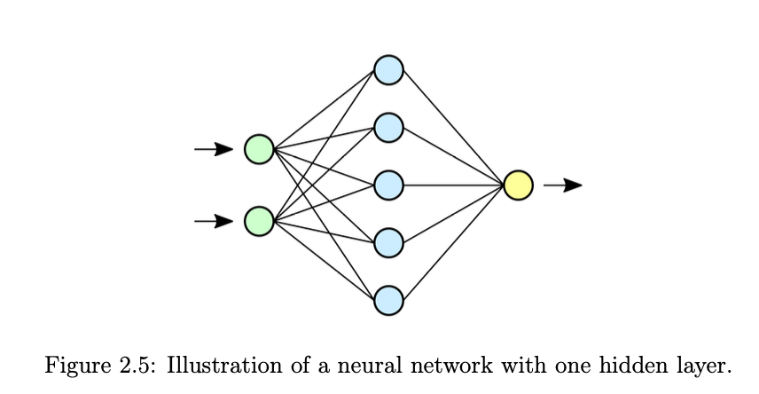

#### Universal Approximation

A special feature of neural networks is that they have to so-called universal approximation property. It means that it can approximate any continuous function on compact subset of $\mathbb{R}^d$.

#### Theorem 2.1.3

Let the activation function $\sigma: \mathbb{R} \to \mathbb{R}$ be piecewise continuous and not a polynomial, and let $f : [0, 1]^d \to \mathbb{R}$ be any continuous function. Then for every $\epsilon > 0$, there exists $n \in \mathbb{N}$ along with weights $\{w_j\}_{j=1,...,n}$ and biases $\{b_j\}_{j=1,...,n}$ such that for the corresponding neural network of the form #2.1.21, it holds that
$$\max_{x \in [0,1 ]^d} |f(x) - \hat{f}(x)| \lt
\epsilon$$
for any $\epsilon >0$, there exists a neural network $\hat{f}$ such that the network $\hat{f}$ can approximate $f$ **uniformly** over $[0, 1]^d$ with arbitrary small error

The proof is relatively simple but requires some profound theorems from functional analysis. It is clear that for polynomial activation functions $\sigma$, the theorem cannot hold. If $\sigma$ is a polynomial of degree $p$, then the same holds for $\hat{f}$ regardless of $n, w_i$ or $b$. An intuition for why the approximation property holds is the following argument, which we formulate for simplicity in the case $d = 1$: Every continuous function $f$ can partition $[0,1 ]$ into $n \in \mathbb{N}$ intervals of the form $I_j := [\frac{j-1}{n}, \frac{j}{n}]$ for $j = 1,...,n$. We define the step function $f_n : [0, 1] \to \mathbb{R}$ by
$$f_n (x) :=
f\biggl(\frac{j}{n}\biggl)$$
where $j \in \{1,..., n\}$ is chosen such that $x \in I_j$. Now let $\epsilon > 0$ be given. Since $f$ is continuous on $[0, 1]$ and therefore uniformly continuous, there exists $n \in \mathbb{N}$ such that for all $x, y \in [0,1 ]$ with $|x-y| \leq \frac{1}{n}$, it holds that $|f(x) -f(y)| \lt \epsilon$. Let $x \in [0, 1]$ be arbitrary and let $j \in \{1,...,n\}$ be such that $x \in I_j$. Then it follows that
$$|f(x) -
f_n (x)| = |f(x) - f\biggl(\frac{j}{n}\biggl) | \lt \epsilon$$
Since $x$ in $[0,1 ]$ was arbitrary, we obtain
$$\sup_{x \in [0, 1]}|f(x) - f_n(x)| \lt
\epsilon$$
It remains to show that each step function can be approximated by neural networks of the form #2.1.21. Here, we also restrict ourselves to a special case and consider the Heaviside activation $\sigma(t) = 1_{t > 0}$. It suffices to show that such neural networks can approximate a step function. Let $f(x) = 1_{s \lt x \leq t}$ for $s < t$ be a step function. Then choose $n =2, a_1 = 1, w_1 = 1, b_1 = -s, a_2 = -1, w_2 = 1, b_2 = -t$ and obtain according to #2.1.21
$$\sum_{j=1}^2
a_j \sigma(\langle w_j, x \rangle + b_j)$$
$$= 1 \sigma(\langle 1, x\rangle -s) + (-1\sigma(\langle 1, x\rangle - t))$$
$$= \sigma(x - s) - \sigma(x - t)$$
Its the same as written below (copied from script)
$$\hat{f}(x) = \sigma(x-s)-\sigma(x-t)= 1_{s \lt x
\leq t} = f(x)$$

#### Training Neural Networks

As with linear regression, we can use the least squares method to determine the parameters of $\hat{f}$. For this, we consider the problem

#### 2.1.22

$$\min_{\substack{a \in \mathbb{R}^n, \\ W
\in \mathbb{R}^{d \times n} \\ b \in \mathbb{R}^n}} \biggl \{
\mathcal{L}(a, W, b) := \frac{1}{2N} \sum_{i=1}^N |a^T \sigma(W^Tx_i +
b) - y_i|^2 \biggl \}$$
where we abbreviate $a = (a_1,...,a_n), W=(w_1,...,w_n)$ and $b = (b_1,...,b_n)$ and we used the fact that
$$\sum_{j=1}^n a_j \sigma(\langle
w_j, x \rangle + b_j) = a^T \sigma(W^Tx +b)$$
To determine the parameters $a, W$, and $b$, we use a gradient descent method. Let $L : \mathbb{R}^P \to \mathbb{R}$ be a continuously differentiable function. Then we denote
$$\begin{cases}
\text{Initialize } x^0 \in \mathbb{R}^P \\
x^k := x^{k-1}- \tau \nabla L(x^{k-1}), & k \in \mathbb{N}
\end{cases}$$
This is the gradient descent method for $L$ with step size $\tau > 0$. We want to apply this function $\mathcal{L}(a, W, b)$ and compute the gradients with respect to the three groups of variables. To do this, we define the residual
$$\text{res}(x_i) := a^T \sigma(W^Tx_i + b) -
y_i$$
and we obtain
$$\nabla_a
\mathcal{L}(a, W, b) = \frac{1}{N} \sum_{i = 1}^N [\text{res}(x_i)
\sigma (W^T x_i + b)] \in \mathbb{R}^n$$
$$\nabla_W \mathcal{L}(a, W, b) = \frac{1}{N}
\sum_{i=1}^N [\text{res}(x_i) a \odot \sigma'(W^T x + b)x_i^T]^T \in
\mathbb{R}^{d \times n}$$
$$\nabla_b
\mathcal{L}(a, W, b) = \frac{1}{N} \sum_{i=1}^N [\text{res}(x_i) a \odot
\sigma'(W^T x + b)]\in \mathbb{R}^n$$
where $\odot$ defines the Hadamard-Product (element-wise product)

#### Definition (Hadamard product)

For two matrices $A$ and $B$ of the same dimension $m \times n$, the Hadamard product $A \odot B$ is a matrix of the same dimension as the operands, with elements given by
$$(A \odot B)_{ij} = (A)_{ij}(B)_{ij}$$
For matrices of different dimensions the Hadamard product is undefined. For example, the Hadamard product for two arbitrary $2 \times 3$ matrices is:
$$\begin{bmatrix}
2 & 3 & 1 \\
0 & 8 & -2
\end{bmatrix}
\odot
\begin{bmatrix}
3 & 1 & 4 \\
7 & 9 & 5
\end{bmatrix}
=
\begin{bmatrix}
2 \cdot 3 & 3 \cdot 1 & 1 \cdot 4 \\
0 \cdot 7 & 8 \cdot 9 & -2 \cdot 5
\end{bmatrix}
= \begin{bmatrix}
6 & 3 & 4 \\
0 & 72 & -10
\end{bmatrix}$$
**Properties**: - $A \odot B = B \odot A$ - $A\odot (B \odot C) = (A \odot B) \odot C$ - $A \odot (B + C) = A \odot B + A \odot C$ - $(kA) \odot B = A \odot (kB) = k (A \odot B)$ - $A \odot 0 = 0$

#### Explanation how the gradients are derived

Remember the Loss function is the MSE:
$$\mathcal{L}(a, W, b) = \frac{1}{2N} \sum_{i=1}^N
|a^T \sigma(W^Tx_i + b) - y_i|^2$$

##### Explanation for gradient w.r.t. $a$

Remember the chain rule and set $f(x) = x^2$ and $g(x) = a^T \sigma(W^Tx_i + b) - y_i$ By applying $f'(g(x)) \cdot g'(x)$ Focus on single weight $a_j$ (the $j$-th component of $a$):
$$\frac{\partial \mathcal{L}}{\partial a_j} =
\frac{1}{N}\sum_{i=1}^N (a^T \sigma(W^Tx_i+b) - y_i) \cdot
\sigma(\langle w_j, x_i \rangle + b_j)$$
where $(a^T \sigma(W^Tx_i+b) - y_i)$ is the residual (prediction error for $x_i$) Alternatively we could do it like this:
$$\mathcal{L}(a, W, b) = \frac{1}{2N} \sum_{i=1}^N
\text{res}(x_i)^2$$
Now compute $\nabla_a \mathcal{L}$ by differentiating $\mathcal{L}$ with respect to each component $a_j$ of $a$ Applying the **chain rule** For each term $\text{res}(x_i)^2$:
$$\frac{\partial}{\partial a_j} \text{res}(x_i)^2 =
2 \cdot \text{res}(x_i) \cdot \frac{\partial}{\partial a_j}
\text{res}(x_i)$$
The derivative of $\text{res}(x_i)$ with respect to $a_j$ is:
$$\frac{\partial}{\partial a_j}[a^T \sigma (W^T x_i
+ b) - y_i] = \sigma (w^T_j x_i + b_j)$$
Here, $w_j$ is the $j$-th column of $W$, and $\sigma(W^Tx_i + b)$ evaluated element-wise Now combining those components we get:
$$\nabla_a \mathcal{L} = \frac{1}{N}\sum_{i=1}^N
\text{res}(x_i) \cdot \sigma(W^T x_i + b)$$

##### Explanation for gradient w.r.t. $W$

Remember,
$$\mathcal{L}(a, W, b) =
\frac{1}{2N} \sum_{i=1}^N \text{res}(x_i)^2, \hspace{0.6cm}
\text{res}(x_i) = a^T\sigma(W^Tx_i + b) - y_i$$
Expanding $\text{res}(x_i)$ using the columns $w_j$ of $W$ we get:
$$\text{res}(x_i) = \sum_{j=1}^n a_j \sigma(w_j^T
x_i + b_j) - y_i$$
Now computing the gradient for the derivative of $\mathcal{L}$ w.r.t one column $w_j$
$$\frac{\partial \mathcal{L}}{\partial w_j} =
\frac{1}{N} \sum_{i=1}^N \text{res}(x_i) \cdot \frac{\partial}{\partial
w_j} (a^T \sigma(W^Tx_i + b) - y_i)$$
Now focus on the last term where we have to compute the gradient for the residual:
$$\frac{\partial}{\partial w_j}(a^T \sigma(W^T x_i
+b) -y_i) = \frac{\partial}{\partial w_j} (a^T \sigma(W^Tx_i + b)) -
\frac{\partial}{\partial w_j}y_i$$
Notice that $y_i$ is a constant and does not depend on $w_j$ thus it disappears So we have to focus on
$$\frac{\partial}{\partial w_j}
(a^T \sigma(W^Tx_i + b)) = \frac{\partial}{\partial w_j}
(a_j\sigma(w_j^Tx_i + b_j)) = a_j \sigma'(w_j^Tx_i + b_j) \cdot
\frac{\partial}{\partial w_j} (w_j^T x_i + b_j)$$
The derivative of
$$\frac{\partial}{\partial w_j} (w_j^T x_i
+ b_j) = x_i$$
since $w_j$ is a vector and $w_j^T x_i$ is linear in $w_j$ Combining the results we get:
$$\frac{\partial}{\partial w_j} (a^T
\sigma(W^Tx_i + b)) = a_j\sigma'(w_j^Tx_i + b_j)x_i$$
The **almost finished gradient** $\nabla_W \mathcal{L}$ aggregates derivatives for all columns $w_1, ..., w_n$. For each data point $x_i$:
$$\nabla_W \mathcal{L} = \frac{1}{N} \sum_{i=1}^N
\text{res}(x_) \cdot [a \odot \sigma'(W^Tx_i+b)]x_i^T$$
where $[a \odot \sigma'(W^Tx_i + b)]$ is a vector with components $a_j \sigma'(w_j^T x_i + b_j)$ The outer product $x_i^T \in \mathbb{R}^{1 \times d}$ ensures the gradient $\nabla_W \mathcal{L}$ matches $W$’s dimensions. $[a \odot \sigma'(W^Tx_i + b)] \in \mathbb{R}^{n \times 1}$. BUT this doesn’t match the dimensions of $W$ ($d \times n$) for now, the gradient gives us a $n \times d$ matrix because of the dimensions described above. Because of this we have to transpose everything, so the **FULL** gradient is:
$$\nabla_W \mathcal{L} = \frac{1}{N} \sum_{i=1}^N
[\text{res}(x_i) a \odot \sigma'(W^Tx+b)]x_i^T]^T, \hspace{0.6cm}
\mathbb{R}^{d \times n}$$

##### Explanation for gradient w.r.t. $b$

Remember
$$\mathcal{L}(a, W, b) =
\frac{1}{2N} \sum_{i=1}^N \text{res}(x_i)^2, \hspace{0.6cm}
\text{res}(x_i) = a^T\sigma(W^Tx_i + b) - y_i$$
$$\frac{\partial}{\partial b} =
\frac{1}{N}\sum_{i=1}^N \text{res}(x_i) \cdot \frac{\partial}{\partial
b} (a^T \sigma(W^Tx_i + b) - y_i)$$
Compute the derivative of the activation function using the chain rule
$$\frac{\partial}{\partial b} \sigma(W^T x_i + b) =
\sigma'(W^Tx_i + b)$$
The gradient of $\frac{\partial}{\partial x}(a^T \sigma(x)) = a \odot \sigma'(x)$, since this is out outer function. Remember the chain rule $f'(g(x)) \cdot g'(x)$ The $\odot$ symbol represents the Hadamard product (element-wise multiplication) between two vectors. The reason the Hadamard is taken is that when you differentiate the scalar output $a^T \sigma(W^Tx_i + b)$ with respect to $b$ is essentially a vector where each element corresponds to the gradient of the respective output dimension. The Hadamard product allows you to combine this vector with the residual, where element-wise multiplication is necessary to correctly propagate the gradient.

The final gradient is thus:
$$=
\frac{1}{N}\sum_{i=1}^N \text{res}(x_i) \cdot a \odot \sigma'(W^Tx_i
+ b)] \in \mathbb{R}^n$$

#### Now back to the script

Thus, the gradient descent procedure in this case is given by
$$\begin{cases}
\text{Initialize }a \in \mathbb{R}^n, W \in \mathbb{R}^{d \times n}, b
\in \mathbb{R}^n \\
\text{For } k \in \mathbb{N} \text{ iterate}: \\
\\
\begin{align}
a^k &:= a^{k-1} - \tau \nabla_a \mathcal{L}(a^{k-1}, W^{k-1},
b^{k-1}) \\
W^k &:= W^{k-1} - \tau \nabla_W \mathcal{L}(a^{k-1}, W^{k-1},
b^{k-1}) \\
b^k &:= b^{k-1} - \tau \nabla_b \mathcal{L}(a^{k-1}, W^{k-1},
b^{k-1})
\end{align}
\end{cases}$$
$a, W$ and $b$ start with random values (e.g. sampled from a normal distribution)

Since the number of data points $N \in \mathbb{N}$ is typically very large, a stochastic gradient method with batch size $B \lt\lt N$ is usually employed:
$$\begin{cases}
\text{Initialize }a \in \mathbb{R}^n, W \in \mathbb{R}^{d \times n}, b
\in \mathbb{R}^n \\
\text{For } k \in \mathbb{N} \text{ iterate}: \\
\text{Choose a random }B\text{-element subset } \mathcal{I} \text{ from
} \{1, ..., N\}\\
\\
\begin{align}
a^k &:= a^{k-1} - \tau \hat{\nabla}_a \mathcal{L}(a^{k-1}, W^{k-1},
b^{k-1}) \\
W^k &:= W^{k-1} - \tau \hat{\nabla}_W \mathcal{L}(a^{k-1}, W^{k-1},
b^{k-1}) \\
b^k &:= b^{k-1} - \tau \hat{\nabla}_b \mathcal{L}(a^{k-1}, W^{k-1},
b^{k-1})
\end{align}
\end{cases}$$
where
$$\hat{\nabla}_a
\mathcal{L}(a, W, b) := \frac{1}{B} \sum_{i \in
\mathcal{I}}[\text{res}(x_i) \sigma(W^Tx_i + b)]$$
and analogously for the $W$ and $b$ variables. (just change $N$ with the batch size $B$)
$$\hat{\nabla}_W \mathcal{L}(a, W, b) = \frac{1}{B}
\sum_{i=1}^N [\text{res}(x_i) a \odot \sigma'(W^T x +
b)x_i^T]^T$$
$$\hat{\nabla}_b
\mathcal{L}(a, W, b) = \frac{1}{B} \sum_{i=1}^N [\text{res}(x_i) a \odot
\sigma'(W^T x + b)]$$
The random subset $\mathcal{I}$ changes in each iteration Although neural networks of the form #2.1.21 have the universal approximation property, deep neural networks are often used in practice. These are obtained by nesting individual layers as shown in #2.1.21 To this end, we choose a depth $L \in \mathbb{N}$, activation functions $\sigma_l : \mathbb{R} \to \mathbb{R}$ (activation function for layer $l$, bias terms $b_l \in \mathbb{R}^{n_l}$ and weight matrices $W^{d_l \times n_l}$ (weight matrix or layer $l$). Here $d_l \in \mathbb{N}$ is the input dimension and $n_l \in \mathbb{N}$ is the number of neurons in the $l$-th layer. We define the $l$-th layer of the neural network as
$$\Phi_l(x) :=
\sigma_l(W_l^Tx+b_l), \hspace{0.5cm} x \in \mathbb{R}^{d_l}$$
and define a neural network as
$$\hat{f}(x) :=
\Phi_L \circ \Phi_{L-1} \circ \dots \circ \Phi_1(x), \hspace{0.6cm} x
\in \mathbb{R}^d$$
where we set $d_1 := d$ (the first layer takes the raw input $x \in \mathbb{R}^d$ and also assume that $d_{l+1} = n_l$ (the output of layer $l$ becomes the input to layer $l+1$) for $l \in \{1,..., L-1\}$. The output dimension $n_L$ is equal to $1$ for the scalar-valued neural networks but can also be greater than $1$ in the case of multidimensional regression. **Example** for $L = 3$:
$$\hat{f}(x) =
\sigma_3(W_3^T\sigma_2(W_2^T\sigma(W_1^Tx + b_1) + b_2) +
b_3)$$

Typically, the activation functions $\sigma_1, \dots, \sigma_{L-1}$ are chosen to be the same (e.g. $\text{ReLU}$ or $\text{Sigmoid}$). However, for $\sigma_L$, it is usually chosen as $\sigma_L(x) = x$ to preserve the universal approximation property of the inner layers We now consider a generalization of the least squares problem #2.1.22 by using more general loss functions

#### 2.1.24

$$\min_{\substack{W_l \in \mathbb{R}^{d_l
\times n_l} \\ b_l \in \mathbb{R}^{n_l} \\ l = 1,..., L}} \biggl\{
\mathcal{L}(a, W, b):= \frac{1}{N} \sum_{i=1}^N \ell(\hat{f}(x_i), y_i)
\biggl\}$$
where $\ell : \mathbb{R}^{n_L \times n_L}$ denotes a loss function (e.g. $\ell(\tilde{y}, y) = \frac{1}{2}|\tilde{y} - y|^2$), and we suppress in our notation that $\hat{f}$ depends on the sought parameters $W_l, b_l$ (all weight matrices and biases across layers)

#### Backpropagation

$$\frac{d\ell (\hat{f}(x), y)}{d
(W_l)_{ij}} = (z_{l-1})_i (\delta_l)_j$$

$$\frac{d\ell (\hat{f}(x), y)}{d
(b_l)_{ij}} = (\delta_l)_j$$
Where $z_{l-1}$ is the output from the previous layer! Backpropagation computes gradients of the loss $\ell (\hat{f}(x), y)$ with respect to weights $W_l$ and biases $b_l$. It works by:

- Forward Pass: Compute predictions $\hat{f}(x)$ and intermediate layer outputs $z_l$
- Backward Pass: Propagate the “error” $\delta_l$ backward through the network to compute the gradients

$\delta_l \in \mathbb{R}^n_l$: The “error” at layer $l$, defined as:
$$\delta_l = \frac{\delta_l}{\delta
a_l}$$
This quantifies how sensitive the loss is to changes in the pre-activation $a_l$ Now on to explaining $\frac{d\ell (\hat{f}(x), y)}{d (W_l)_{ij}} = (z_{l-1})_i (\delta_l)_j$

- $(z_{l-1})_i$: Activation from neuron $i$ in layer $l-1$
- ($\delta_l)_j$: Error at neuron $j$ in layer $l$
- **Why?**
  - The weight ($W_l)_{ij}$ connects neuron $i$ in layer $l-1$ to neuron $j$ in layer $l$. The gradient depends on:
    - How much neuron $i$ in layer $l-1$ was activated ($z_{l-1}$)
    - How much error is attributed to neuron $j$ in layer $l$ ($\delta_l$)

Now on to explaining $\frac{d\ell (\hat{f}(x), y)}{d (b_l)_{ij}} = (\delta_l)_j$

- This is the error at neuron $j$ in layer $l$
- **Why?**
  - The bias $(b_l)_j$ directly offsets the pre-activation $a_l$. Its gradient is purely the error at neuron $j$

Next up: 2.2 Classification